# 02 · Detectar procesos automatizables

## Detectar procesos automatizables

02 · DEL PROBLEMA OBSERVADO A UN PILOTO JUSTIFICABLE

Detectar procesos  
automatizables

**Análisis de procesos, evidencia y priorización con Python**

Caso conductor: observatorio territorial de deuda tributaria publicada.

Datos de aula completamente ficticios.

## Del funcionamiento técnico a la oportunidad adecuada

En el tema 01 aprendimos a describir una automatización y a comprobar su resultado. Ahora debemos decidir **qué parte del trabajo conviene cambiar**.

Una operación repetitiva puede ser poco valiosa, inestable o estar rodeada de excepciones que hacen inviable el alcance inicial.

**Pregunta de negocio**

¿Dónde podemos mejorar el proceso con evidencia suficiente y un alcance que podamos controlar?

La respuesta debe explicar beneficio, esfuerzo, incertidumbre y responsabilidad.

## Qué entregaremos al finalizar

| Evidencia | Qué debe contener |
| --- | --- |
| Ficha de proceso | Inicio, fin, unidad de trabajo, responsable y resultado. |
| Mapa del estado actual | Pasos reales, esperas, decisiones y excepciones. |
| Línea base | Volumen, esfuerzo y calidad con fuente de medición. |
| Comparación de oportunidades | Filtros, puntuaciones y sensibilidad. |
| Propuesta de piloto | Alcance, métricas de aceptación y revisión. |

## El límite con los demás temas

Este bloque desarrolla observación, modelado sencillo, estimación de carga, priorización y diseño de un piloto. Python se utiliza para **calcular y contrastar escenarios**.

**Se implementará después**

Archivos y lotes en 03–06. Excel, PDF e informes en 07–11. APIs y web en 12–15. IA, interfaces y agentes en sus temas.

Aquí identificamos requisitos, no enseñamos todavía esas herramientas.

## Proceso, tarea y actividad necesitan una frontera

| Nivel | Ejemplo | Frontera útil |
| --- | --- | --- |
| Proceso | Preparar el informe territorial de una edición. | Desde recibir la publicación hasta aprobar el informe. |
| Tarea | Validar registros del listado. | Desde datos estructurados hasta aceptados e incidencias. |
| Actividad | Comprobar el tipo del año. | Una regla dentro de la tarea de validación. |

Una oportunidad demasiado amplia mezcla decisiones distintas. Una demasiado pequeña puede ahorrar segundos y dejar intacto el problema principal.

## La unidad de trabajo define el denominador

Un volumen de 12.000 significa poco si no sabemos si son filas, archivos, expedientes o ejecuciones. El tiempo por unidad debe utilizar **el mismo denominador**.

También hay que fijar periodo: una edición, un mes o un año.

**P02 en el laboratorio**

Unidad: registro. Volumen: 12.000 registros/año. Esfuerzo manual: 0,80 minutos/registro.

No multiplicamos registros por minutos de un lote completo.

## Una ficha permite discutir el mismo proceso

| Campo | Pregunta que aclara |
| --- | --- |
| Objetivo y cliente del resultado | ¿Qué decisión o necesidad atiende? |
| Inicio y final | ¿Qué evento lo activa y cuándo se considera terminado? |
| Entrada y salida | ¿Qué recibe y qué entrega exactamente? |
| Unidad y volumen | ¿Qué contamos y en qué periodo? |
| Responsable y participantes | ¿Quién decide y quién realiza los pasos? |
| Reglas y excepciones | ¿Qué está acordado y qué necesita revisión? |

## Observar trabajo real evita automatizar una descripción ideal

La entrevista ayuda a conocer objetivos y dificultades. La observación muestra desvíos: buscar la versión correcta, corregir formatos o solicitar información.

Combina relatos, ejemplos de entradas y salidas, registros disponibles y observación de varias situaciones.

**Evidencia y confianza**

«Normalmente tardamos diez minutos» es una estimación.

Ocho observaciones fechadas aportan más detalle, pero pueden seguir sin representar el cierre mensual.

## El trabajo invisible cambia la estimación

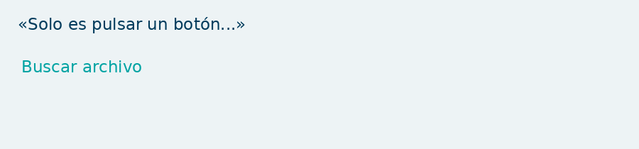

Un gesto sencillo puede depender de una preparación larga. Si medimos únicamente el clic final, subestimamos el esfuerzo real y también la revisión que seguirá siendo necesaria.

## SIPOC ofrece una vista de contexto

| Elemento | Ejemplo del informe territorial |
| --- | --- |
| Proveedores | Publicador del listado, responsable de datos de contexto. |
| Entradas | Edición, metadatos, correspondencia territorial validada. |
| Proceso | Preparar, validar, contextualizar y revisar. |
| Salidas | Informe y evidencias de su elaboración. |
| Destinatarios | Equipo autorizado que revisa o utiliza el informe. |

SIPOC delimita relaciones. No sustituye el mapa detallado ni describe por sí solo los controles.

## El mapa AS-IS representa cómo se trabaja hoy

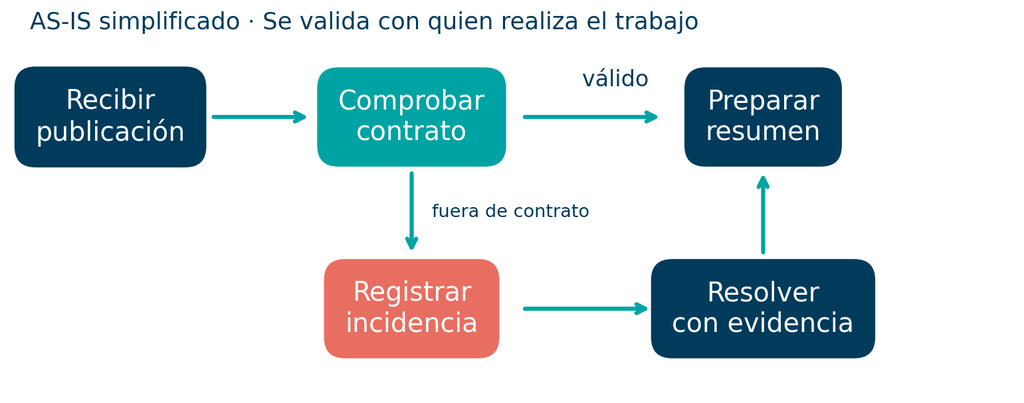

El mapa incluye una ruta normal y otra de revisión. Debe contrastarse con quienes hacen el trabajo y con ejemplos de casos que salen de la ruta habitual.

## Las decisiones necesitan condiciones observables

«Si está bien, continuar» oculta el criterio. Sustitúyelo por una condición comprobable: columnas presentes, periodo compatible o clave territorial contrastada.

Cada decisión necesita una ruta cuando la condición no se cumple.

**Ejemplo de precisión**

Antes: «Revisar el fichero».

Después: «Comprobar las columnas requeridas y registrar qué falta; detener el lote si el contrato global es incompatible».

## Tiempo de trabajo y tiempo de espera explican problemas distintos

| Medida | Qué captura | Ejemplo |
| --- | --- | --- |
| Esfuerzo activo | Tiempo dedicado por una persona. | Ocho minutos revisando un lote. |
| Espera | Tiempo sin trabajar sobre ese caso. | Dos días hasta recibir una corrección. |
| Tiempo de ciclo | Tiempo transcurrido entre inicio y fin definidos. | Desde recepción hasta aprobación. |

Automatizar ocho minutos puede no resolver una espera de dos días. La mejora necesaria podría ser acordar responsabilidades o requisitos de entrada.

## Una línea base necesita distribución y contexto

```python
from statistics import mean, median

tiempos = [5, 5, 6, 6, 7, 7, 8, 20]
print(mean(tiempos))    # 8.0 minutos
print(median(tiempos))  # 6.5 minutos
```

La media incorpora el caso largo. La mediana representa el centro de esta muestra. Ninguna resume por sí sola todos los casos.

Registra periodo observado, tamaño de muestra, unidad, qué incluye el tiempo y cómo se han tratado interrupciones.

## Frecuencia anual y estacionalidad

Para estimar carga anual, combina frecuencia y unidades por ejecución.

Por ejemplo, 12 ediciones con 1.000 registros comparables producen 12.000 registros/año. Pero el mismo total anual puede concentrarse en una semana.

**Capacidad y plazo**

Un ahorro anual positivo no garantiza llegar al cierre.

Registra también el pico de demanda y el tiempo máximo admisible para entregar el resultado.

## Las excepciones forman parte del proceso

| Tipo | Ejemplo | Efecto sobre el diseño |
| --- | --- | --- |
| Entrada fuera de contrato | Falta una columna necesaria. | Rechazar o devolver para corrección. |
| Caso de negocio no cubierto | Dos versiones con importes distintos. | Resolver con una persona responsable. |
| Fallo técnico | Fuente no disponible temporalmente. | Definir recuperación y cuándo detenerse. |
| Decisión pendiente | No existe criterio territorial acordado. | Aclarar la regla antes del piloto. |

## La proporción de excepciones necesita el denominador correcto

$$p_e=\frac{N_{unidades\ con\ trabajo\ adicional}}{N_{unidades\ observadas}}$$

Con 8 registros que necesitan intervención adicional entre 100 observados, $p_e=0,08$. En Python guardamos **0,08**, no 8.

Contamos unidades, no eventos: si una fila produce tres avisos, no se convierte en tres registros con excepción. Si no hay observaciones, desconocemos la proporción.

## Antes de automatizar conviene revisar el propio proceso

Una operación puede desaparecer si el dato se captura bien en origen. Otras tareas pueden simplificarse, estandarizarse o integrarse sin desarrollar una automatización nueva.

Automatizar una copia innecesaria conserva su coste y puede hacer más difícil detectar que sobra.

**Ejemplo**

Si dos equipos vuelven a transcribir el mismo dato, investigar una fuente compartida puede aportar más valor que acelerar ambas transcripciones.

La oportunidad consiste en mejorar el resultado del proceso.

## El TO-BE debe explicar qué cambia y qué permanece

| Elemento | Estado actual | Propuesta inicial |
| --- | --- | --- |
| Validación | Revisión manual de todos los registros. | Reglas repetibles y cola de incidencias. |
| Excepciones | Correcciones dispersas. | Motivo, evidencia y responsable definido. |
| Aprobación | Criterio individual poco visible. | Aprobación humana con condiciones explícitas. |
| Medición | Estimaciones retrospectivas. | Línea base y métricas comparables. |

## Los filtros previos evitan compensar una carencia crítica

Antes de ordenar oportunidades, revisamos autorización, responsable, evidencia suficiente y riesgo. Una buena estimación de ahorro no resuelve una falta de permiso.

Un dato desconocido debe quedar pendiente, con una acción para obtenerlo.

**Política docente del caso**

Autorización denegada: bloqueado. Información esencial ausente: pendiente. Riesgo 4–5: rediseñar alcance y controles.

Estos filtros no sustituyen una evaluación normativa real.

## El riesgo se analiza como escenario y control

Describe qué podría ocurrir, qué consecuencia tendría y cómo se detectaría. «Riesgo alto» sin un escenario concreto no permite diseñar controles.

Por ejemplo: asociar un registro al municipio equivocado puede producir una interpretación territorial incorrecta.

**Respuesta de diseño**

Conservar la fuente de correspondencia, separar coincidencias dudosas y exigir revisión antes de difundir el resultado.

El control debe poder comprobarse durante el piloto.

## La cartera contiene ocho oportunidades ficticias

| ID | Oportunidad | Unidad | Volumen anual |
| --- | --- | --- | --- |
| P01 | Organizar evidencias | archivo | 2,400 |
| P02 | Validar registros | registro | 12,000 |
| P03 | Preparar informes | informe | 48 |
| P04 | Resolver territorio | registro | 6,000 |
| P05 | Preparar correos | correo | 52 |
| P06 | Publicar datos nominales | publicación | 12 |
| P07 | Interpretar normativa | consulta | 24 |
| P08 | Contrastar fuentes | contraste | 120 |

Las oportunidades pertenecen al mismo proyecto. **Sus beneficios no se suman automáticamente:** puede haber dependencias y trabajo compartido.

## Modelo de esfuerzo futuro: trabajo humano residual

$$t_f=t_o+t_r+p_e\,t_e$$

$t_o$: intervención humana operativa por unidad. $t_r$: revisión humana habitual por unidad. $p_e$: proporción de unidades con excepción. $t_e$: minutos humanos **adicionales** por unidad con excepción.

Todos los tiempos son esfuerzo humano, en minutos por unidad. El tiempo de CPU o la espera de una descarga no se resta como si fueran horas de trabajo de una persona.

## P02: del supuesto a los minutos esperados

```python
min_operacion = 0.02
min_revision = 0.03
p_excepcion = 0.08
min_excepcion = 2

min_futuros = (min_operacion
    + min_revision
    + p_excepcion * min_excepcion)
# 0.21 minutos por registro
```

Cada registro necesita 0,05 minutos habituales. El ocho por ciento necesita además dos minutos. El promedio futuro es 0,21 minutos por registro.

El actual es 0,80 minutos por registro. La diferencia estimada es **0,59 minutos por registro**.

## De minutos por unidad a horas anuales

$$H_m=\frac{Vt_m}{60}\qquad H_f=\frac{Vt_f}{60}$$

$$H_b=H_m-H_f$$

Para P02: $V=12.000$, $H_m=160$ h/año y $H_f=42$ h/año. El ahorro bruto de esfuerzo es **118 horas/año**.

«Bruto» indica que todavía no hemos descontado implantación ni mantenimiento.

## Implantación y mantenimiento cambian la decisión

$$H_{neto,1}=H_b-H_i-H_{mant}$$

$$H_{neto,rec}=H_b-H_{mant}$$

P02 necesita 28 horas de implantación y 12 de mantenimiento anual. Primer año: $118-28-12=78$ horas netas. Años posteriores, bajo los mismos supuestos: **106 horas netas/año**.

El primer año y un año recurrente responden a preguntas diferentes. No vuelvas a descontar la implantación cada año si es un esfuerzo inicial único.

## Capacidad liberada y ahorro económico son conceptos distintos

Las horas estimadas pueden convertirse en capacidad para revisar más casos, reducir retrasos o mejorar cobertura. No implican por sí solas una reducción de gasto.

Para un análisis económico harían falta costes evitables, licencias, infraestructura y un horizonte acordado.

**Lenguaje del caso**

«Se estiman 78 horas netas de capacidad durante el primer año».

No afirmamos «se ahorrará esa cantidad multiplicada por el salario» sin comprobar cómo se materializa.

## Recuperación del esfuerzo inicial

$$M=12\frac{H_i}{H_b-H_{mant}}\quad\text{si }H_b>H_{mant}$$

En P02: $M=12\cdot28/106\approx3,17$ meses.

La estimación supone volumen y mantenimiento uniformes durante el año. Con estacionalidad, el calendario de recuperación cambia. Si el beneficio recurrente no es positivo, el modelo devuelve **sin recuperación estimada**.

## Los resultados de esfuerzo no tienen por qué ser positivos

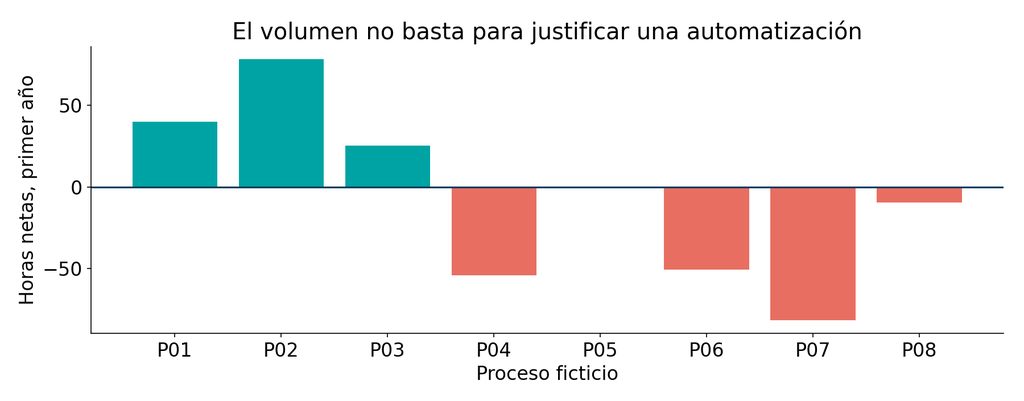

P01, P02 y P03 tienen balance positivo en el escenario base. Una barra negativa invita a revisar alcance o supuestos; no demuestra que el proceso carezca de valor de calidad o de servicio.

## Una puntuación ayuda a discutir criterios diferentes

El modelo docente utiliza seis factores: volumen, estabilidad, estructura, calidad, impacto y facilidad. Cada uno recibe una valoración de 1 a 5, sustentada en evidencia.

Los pesos expresan una preferencia del equipo y suman uno. **No son una norma ni una fórmula universal de éxito.**

La puntuación ordena una conversación. Los filtros previos deciden qué alternativas están en condiciones de entrar en esa conversación como candidatas a piloto.

## La rúbrica necesita anclajes observables

| Factor | 1: evidencia desfavorable | 3: situación intermedia | 5: evidencia favorable |
| --- | --- | --- | --- |
| Volumen | Carga baja en el contexto. | Carga moderada. | Carga elevada comparable. |
| Estabilidad | Cambios frecuentes sin criterio. | Parte de las reglas estable. | Reglas acordadas y estables. |
| Estructura | Entrada heterogénea. | Estructura parcial. | Contrato uniforme disponible. |
| Calidad | Errores frecuentes sin trazabilidad. | Problemas conocidos. | Datos contrastados y medidos. |
| Impacto | Mejora poco relevante. | Mejora acotada. | Resultado relevante para el servicio. |
| Facilidad | Dependencias sin resolver. | Integración viable con trabajo. | Acceso e integración sencillos. |

## Pesos y normalización de la escala

| Factor | Peso docente |
| --- | --- |
| Volumen | 20 % |
| Estabilidad | 20 % |
| Estructura | 15 % |
| Calidad | 15 % |
| Impacto | 20 % |
| Facilidad | 10 % |

$$S=100\sum_j w_j\frac{s_j-1}{4}\qquad\sum_j w_j=1$$

## P02: una puntuación que podemos reconstruir

```python
factores = {
    "volumen": 5, "estabilidad": 5,
    "estructura": 5, "calidad": 4,
    "impacto": 5, "facilidad": 4,
}

score = puntuar(factores, PESOS)
print(score)  # 93.75
```

La calidad y la facilidad no alcanzan el nivel máximo. Sus contribuciones normalizadas son 0,75 en lugar de 1.

La puntuación final es **93,75 sobre 100** con esta rúbrica. Su interpretación depende de que las valoraciones tengan evidencia suficiente.

## Los datos desconocidos no se rellenan con una opinión

```python
factores_incompletos = {
    **factores, "calidad": None
}
print(puntuar(
    factores_incompletos, PESOS
))  # None
```

Una valoración desconocida deja la oportunidad pendiente. El siguiente paso es obtener evidencia: observar una muestra, consultar al responsable o contrastar un contrato de entrada.

Sustituirla por cero penaliza incertidumbre como si fuera mala calidad. Sustituirla por tres simula un conocimiento que no existe.

## Cómo se toma la decisión en el laboratorio

| Orden | Condición | Estado |
| --- | --- | --- |
| 1 | Autorización declarada como denegada. | Bloqueado. |
| 2 | Falta autorización, responsable, riesgo o una valoración. | Pendiente de evidencia. |
| 3 | Riesgo valorado como 4–5. | Rediseñar. |
| 4 | Puntuación ≥ 70 y horas netas del año 1 > 0. | Candidato a piloto. |
| 5 | Resto de situaciones completas. | Analizar alternativas. |

El umbral 70 y el nivel de riesgo son **convenciones de esta práctica**, no requisitos de producción.

## Resultado de la cartera en el escenario base

| ID | Puntuación | Horas netas año 1 | Estado |
| --- | --- | --- | --- |
| P01 | 81.25 | 40.0 | candidato piloto |
| P02 | 93.75 | 78.0 | candidato piloto |
| P03 | 73.75 | 25.2 | candidato piloto |
| P04 | 53.75 | -54.0 | pendiente |
| P05 | 67.50 | -0.3 | analizar |
| P06 | 71.25 | -50.6 | bloqueado |
| P07 | 36.25 | -81.6 | redisenar |
| P08 | — | -9.6 | pendiente |

Los candidatos a piloto se ordenan **P02, P01 y P03**. Los otros procesos conservan su estado y motivo; no desaparecen del análisis.

## Una gráfica no reemplaza la revisión de los filtros

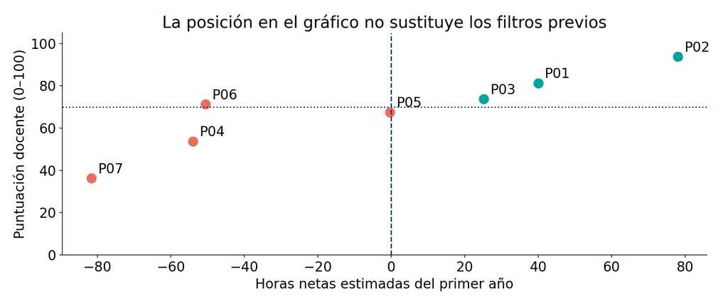

La zona superior derecha resulta atractiva según estos dos ejes. Aun así, necesitamos conocer permisos, responsable, calidad de la evidencia y dependencias.

## Sensibilidad: qué ocurre si hay más excepciones

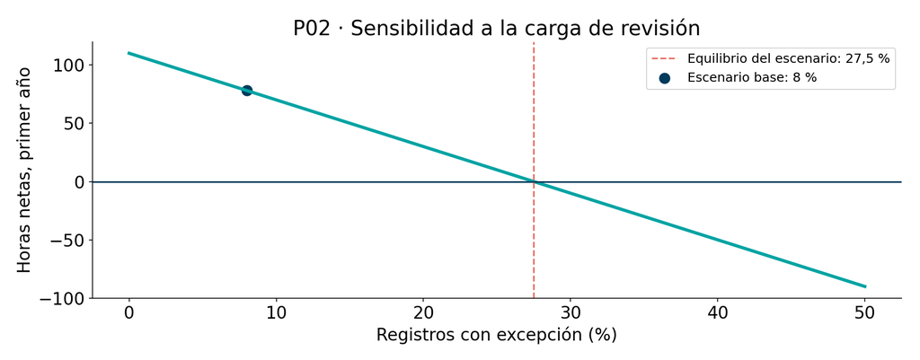

Con 8 % estimamos 78 horas netas. Con 30 % obtenemos **−10 horas**. La decisión cambia aunque la puntuación de factores siga siendo la misma.

## Un umbral de excepción ayuda a formular el piloto

$$p_e^*=\frac{t_m-t_o-t_r-60(H_i+H_{mant})/V}{t_e}$$

Para $V>0$ y $t_e>0$, el equilibrio del primer año de P02 se sitúa en **27,5 %**. Por debajo, el modelo estima horas netas positivas; por encima, negativas.

Si el umbral cae fuera de $[0,1]$, hay que interpretarlo con el dominio del problema. No se convierte automáticamente en una tasa admisible de calidad.

## Los pesos también pueden cambiar el orden

En un escenario centrado en impacto, damos a impacto 50 % y a cada uno de los otros cinco factores 10 %. Con los mismos datos:

| Orden de candidatos | Pesos base | Prioridad al impacto |
| --- | --- | --- |
| 1 | P02 | P02 |
| 2 | P01 | P03 |
| 3 | P03 | P01 |

La primera opción es estable en esta comparación. La segunda y tercera dependen de la preferencia declarada.

## La calidad de la estimación debe acompañar al número

Distingue valores observados, supuestos acordados y estimaciones pendientes. Conserva fuente, periodo y responsable de cada uno.

Un escenario optimista y otro conservador pueden ser más útiles que una cifra única con dos decimales.

**P02 antes del piloto**

12.000 registros/año: hipótesis de volumen. 0,80 min/registro: línea base sintética. 8 % de excepciones: supuesto que debe contrastarse.

La precisión de cálculo no mejora la calidad de esas evidencias.

## Dependencias y beneficios compartidos

Generar informes puede depender de validar registros y resolver correspondencias territoriales. Un proceso con buen valor aislado puede no estar listo para un piloto completo.

No sumes el ahorro de cada ficha si hay trabajo solapado o si la misma mejora se atribuye dos veces.

**Piloto de alcance acotado**

P02 puede probarse con registros sintéticos estructurados antes de integrar descargas y mapas.

P03 necesitará una entrada validada, aunque todavía podamos ensayar una plantilla por separado.

## Una propuesta de piloto responde a una hipótesis

| Elemento | Propuesta para P02 |
| --- | --- |
| Hipótesis | La validación reduce esfuerzo sin perder incidencias relevantes. |
| Alcance | Entrada sintética estructurada y reglas acordadas. |
| Comparación | Resultado manual de referencia frente a salida del piloto. |
| Métricas | Esfuerzo humano, cobertura de controles y resolución de excepciones. |
| Responsable | Persona que aprueba reglas y revisa discrepancias. |
| Salida del piloto | Continuar, modificar o descartar con evidencia. |

## Criterios de aceptación y de detención

Un criterio de aceptación define qué evidencia permitiría avanzar. Por ejemplo, reconciliación completa de filas y coincidencia con casos de referencia previamente revisados.

Un criterio de detención evita continuar cuando el supuesto principal deja de sostenerse.

**Ejemplos del piloto**

Detener si se pierden registros, se altera la entrada o falta autorización.

Revisar alcance si el esfuerzo humano futuro supera la previsión o las excepciones no tienen una persona responsable.

## La práctica de Python organiza la decisión

```python
resultados = evaluar_cartera(
    cartera, PESOS
)
prioridad = ordenar_candidatos(resultados)

for fila in prioridad:
    print(fila["id"],
          fila["puntuacion"])
```

La implementación completa valida unidades numéricas, proporciones, pesos e identificadores de fichas.

Conserva estados y motivos. No modifica la entrada y utiliza un orden estable para empates técnicos. El código calcula una decisión docente; no autoriza ninguna acción externa.

## Doce ejercicios para contrastar el razonamiento

| Ejercicios | Trabajo principal |
| --- | --- |
| 01–03 | Delimitar proceso, medir una muestra y calcular carga anual. |
| 04–06 | Estimar trabajo futuro, descontar costes y reconstruir puntuación. |
| 07–09 | Aplicar filtros, ordenar candidatos y variar excepciones. |
| 10–12 | Validar entradas, discutir pesos y redactar un piloto. |

Cada tarea incluye pista, comprobaciones activables y explicación. Los ejercicios usan la parte guiada y pueden resolverse sin depender de respuestas anteriores.

## Una recomendación defendible muestra sus límites

**Propuesta del escenario base**

Empezar por un piloto acotado de P02. Es candidato con 93,75 puntos y 78 horas netas estimadas del primer año.

La recomendación depende de los supuestos de revisión, excepciones y carga anual.

**Qué todavía no sabemos**

Si los tiempos se mantendrán con una muestra representativa.

Qué esfuerzo real tendrá la integración.

Cómo evolucionarán las reglas y el mantenimiento.

## Cierre y puente al bloque de archivos

Hoy hemos convertido una idea de automatización en una propuesta con frontera, evidencia, supuestos y criterios de revisión.

El tema 03 comenzará a implementar operaciones sobre archivos con `pathlib`. Utilizaremos oportunidades como P01 para conectar rutas y operaciones concretas con requisitos ya definidos.

**Pregunta de salida**

¿Qué dato recogerías antes de automatizar una tarea de tu equipo y qué decisión cambiaría si ese dato fuera distinto?

## Fuentes y naturaleza del modelo

- [Microsoft Learn · Planificar un proyecto de automatización](https://github.com/MicrosoftDocs/power-automate-docs/blob/main/articles/guidance/planning/introduction.md).
- [NHS England · Process mapping, analysis and redesign](https://www.england.nhs.uk/improvement-hub/wp-content/uploads/sites/44/2017/11/ILG-1.2-Process-Mapping-Analysis-and-Redesign.pdf).
- [Python · statistics](https://docs.python.org/3/library/statistics.html) y [math](https://docs.python.org/3/library/math.html).

La cartera, la rúbrica, los pesos y los cortes son **construcciones docentes originales**. Las referencias ofrecen contexto metodológico; no validan estas puntuaciones ni sus umbrales.

Recursos gráficos y GIF originales. Logos recuperados del material de referencia. Revisión: **3 de noviembre de 2026**.